# Predicting Modeling over the Weight Lifting Exercises Dataset

Adrián Gómez

## Overview

The human activity recognition research has traditionally focused on discriminating between different activities, but not “how well” an activity was performed. Given the **Weight Lifting Exercises Dataset** we are going to develop a model to predict if a given exercise is performed correctly or not.

## Exploratory Analysis

The *classe* variable is the outcome, and represent five different ways to do a given exercise. The letter A means that the exercise was performed correctly and the other letters(B-E) are different forms of having performed the exercise incorrectly.

```r
library(caret)
```

```r
library(ggplot2)
pml <- read.csv('pml-training.csv')
```

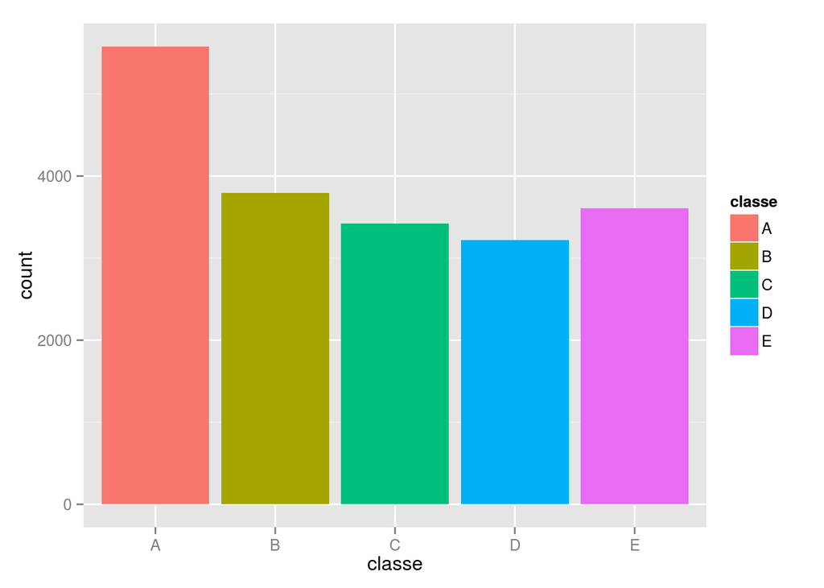

```r
g <- ggplot(pml,aes(classe,fill = classe))
g + geom_bar()
```

## Preprocessing

We removed the columns with lot of NA’s(50%) and the columns with near zero variance. Also we removed some columns which we believe they will not help to build a generalizable model such as X, user_name and some timestamps.

```r
  pml.data <- pml[, colSums(is.na(pml)) < nrow(pml) * 0.5]
  nzv <- nearZeroVar(pml.data,saveMetrics = TRUE)
  pml.data <- pml.data[,!nzv[,4]]
  str(pml.data)
```

```
## 'data.frame':    19622 obs. of  59 variables:
##  $ X                   : int  1 2 3 4 5 6 7 8 9 10 ...
##  $ user_name           : Factor w/ 6 levels "adelmo","carlitos",..: 2 2 2 2 2 2 2 2 2 2 ...
##  $ raw_timestamp_part_1: int  1323084231 1323084231 1323084231 1323084232 1323084232 1323084232 1323084232 1323084232 1323084232 1323084232 ...
##  $ raw_timestamp_part_2: int  788290 808298 820366 120339 196328 304277 368296 440390 484323 484434 ...
##  $ cvtd_timestamp      : Factor w/ 20 levels "02/12/2011 13:32",..: 9 9 9 9 9 9 9 9 9 9 ...
##  $ num_window          : int  11 11 11 12 12 12 12 12 12 12 ...
##  $ roll_belt           : num  1.41 1.41 1.42 1.48 1.48 1.45 1.42 1.42 1.43 1.45 ...
##  $ pitch_belt          : num  8.07 8.07 8.07 8.05 8.07 8.06 8.09 8.13 8.16 8.17 ...
##  $ yaw_belt            : num  -94.4 -94.4 -94.4 -94.4 -94.4 -94.4 -94.4 -94.4 -94.4 -94.4 ...
##  $ total_accel_belt    : int  3 3 3 3 3 3 3 3 3 3 ...
##  $ gyros_belt_x        : num  0 0.02 0 0.02 0.02 0.02 0.02 0.02 0.02 0.03 ...
##  $ gyros_belt_y        : num  0 0 0 0 0.02 0 0 0 0 0 ...
##  $ gyros_belt_z        : num  -0.02 -0.02 -0.02 -0.03 -0.02 -0.02 -0.02 -0.02 -0.02 0 ...
##  $ accel_belt_x        : int  -21 -22 -20 -22 -21 -21 -22 -22 -20 -21 ...
```

[output cut: 45 more lines]

```r
  var.to.remove <- c("X","user_name","raw_timestamp_part_1")
  var.to.remove <- c(var.to.remove,"raw_timestamp_part_2","cvtd_timestamp")
  pml.data <- pml.data[,which(names(pml.data) %in% var.to.remove == FALSE)]
  dim(pml.data)
```

```
## [1] 19622    54
```

## Modeling

The most usual split for a cross-validation is 70% for the train set and 30% for the test set. However, given the size of the dataset and the number of variables looks appropriate to try with a smaller train size first, and then increase the size if the results are not satisfactory. We use 15% for the train set and 85% for the test set.

```r
  set.seed(123)
  inTraining <- createDataPartition(pml$classe,p = .15,list = FALSE)
  pml.train <- pml.data[inTraining,]
  pml.test <- pml.data[-inTraining,]
  model <- train(classe ~ .,data = pml.train,method = "rf")
```

## Results

Even that we only used a 15% of the train set we get a very high accuracy of around 98% on the test set, which is good enough for the present work.

```r
  confusionMatrix(predict(model,newdata = pml.test),pml.test$classe)
```

```
## Confusion Matrix and Statistics
##
##           Reference
## Prediction    A    B    C    D    E
##          A 4717   78    0    1    0
##          B    4 3082   54    2    8
##          C    7   62 2828   64    0
##          D    0    4   20 2661   47
##          E   15    1    6    5 3010
##
## Overall Statistics
##
##                Accuracy : 0.9773
##                  95% CI : (0.975, 0.9795)
##     No Information Rate : 0.2844
##     P-Value [Acc > NIR] : < 2.2e-16
##
##                   Kappa : 0.9713
##  Mcnemar's Test P-Value : < 2.2e-16
##
## Statistics by Class:
##
##                      Class: A Class: B Class: C Class: D Class: E
## Sensitivity            0.9945   0.9551   0.9725   0.9737   0.9821
## Specificity            0.9934   0.9949   0.9903   0.9949   0.9980
## Pos Pred Value         0.9835   0.9784   0.9551   0.9740   0.9911
## Neg Pred Value         0.9978   0.9893   0.9942   0.9948   0.9960
## Prevalence             0.2844   0.1935   0.1744   0.1639   0.1838
## Detection Rate         0.2829   0.1848   0.1696   0.1596   0.1805
## Detection Prevalence   0.2876   0.1889   0.1776   0.1638   0.1821
## Balanced Accuracy      0.9939   0.9750   0.9814   0.9843   0.9900
```

## References

Velloso, E.; Bulling, A.; Gellersen, H.; Ugulino, W.; Fuks, H. Qualitative Activity Recognition of Weight Lifting Exercises. Proceedings of 4th International Conference in Cooperation with SIGCHI (Augmented Human ’13) . Stuttgart, Germany: ACM SIGCHI, 2013.